# IS 362 Final Project

## Project Details

This project will look examine and analyze the correlation between the number of births in New York Counties and the household income in each county.

**Questions:**

1. Has the birth rate declined in New York counties from 2007 to 2016?
2. What are the total incomes per New York county?
3. Are counties with more births have higher incomes?

[figure not shown]

## Data Used

The first data was retrieved from [Centers for Disease Control and Prevention](https://wonder.cdc.gov/). The Natality online database report countsof live births occurring within the United States to U.S. residents and non-residents. Counts can be obtained by state, county, child's gender and weight, etc. The data are derived from birth certificates. For this project, I obtained birth counts by New York county, the year (from 2007 to 2016), and percentage of total births.

The second data I used was retrieved from [The United States Census Bureau](https://www.census.gov/en.html). I used the income in the past 12 months, year 2016. The data shows the total number of population for each county and the percentage of income ranges per country.

## Natality Data

```python
import pandas as pd
import matplotlib.pyplot as plt
```

```python
df = pd.read_csv('Natality_year.csv', sep='\t')
df
```

|  | County | County Code | Year | Year Code | Births | % of Total Births |
| --- | --- | --- | --- | --- | --- | --- |
| NaN | Albany County, NY | 36001 | 2007 | 2007 | 3161 | 0.13% |
| NaN | Albany County, NY | 36001 | 2008 | 2008 | 3085 | 0.13% |
| NaN | Albany County, NY | 36001 | 2009 | 2009 | 3121 | 0.13% |
| NaN | Albany County, NY | 36001 | 2010 | 2010 | 3032 | 0.12% |
| NaN | Albany County, NY | 36001 | 2011 | 2011 | 3076 | 0.13% |
| NaN | Albany County, NY | 36001 | 2012 | 2012 | 3087 | 0.13% |
| NaN | Albany County, NY | 36001 | 2013 | 2013 | 3085 | 0.13% |
| NaN | Albany County, NY | 36001 | 2014 | 2014 | 3109 | 0.13% |
| NaN | Albany County, NY | 36001 | 2015 | 2015 | 3095 | 0.13% |
| NaN | Albany County, NY | 36001 | 2016 | 2016 | 3045 | 0.13% |
| NaN | Bronx County, NY | 36005 | 2007 | 2007 | 22981 | 0.95% |
| NaN | Bronx County, NY | 36005 | 2008 | 2008 | 23144 | 0.95% |
| NaN | Bronx County, NY | 36005 | 2009 | 2009 | 23146 | 0.95% |
| NaN | Bronx County, NY | 36005 | 2010 | 2010 | 22490 | 0.93% |
| NaN | Bronx County, NY | 36005 | 2011 | 2011 | 21873 | 0.90% |
| NaN | Bronx County, NY | 36005 | 2012 | 2012 | 21453 | 0.88% |
| NaN | Bronx County, NY | 36005 | 2013 | 2013 | 21416 | 0.88% |
| NaN | Bronx County, NY | 36005 | 2014 | 2014 | 21556 | 0.89% |
| NaN | Bronx County, NY | 36005 | 2015 | 2015 | 21493 | 0.89% |
| NaN | Bronx County, NY | 36005 | 2016 | 2016 | 21161 | 0.87% |
| NaN | Broome County, NY | 36007 | 2007 | 2007 | 2129 | 0.09% |
| NaN | Broome County, NY | 36007 | 2008 | 2008 | 2076 | 0.09% |
| NaN | Broome County, NY | 36007 | 2009 | 2009 | 2064 | 0.09% |
| NaN | Broome County, NY | 36007 | 2010 | 2010 | 2052 | 0.08% |
| NaN | Broome County, NY | 36007 | 2011 | 2011 | 2060 | 0.08% |
| NaN | Broome County, NY | 36007 | 2012 | 2012 | 2083 | 0.09% |
| NaN | Broome County, NY | 36007 | 2013 | 2013 | 2068 | 0.09% |
| NaN | Broome County, NY | 36007 | 2014 | 2014 | 2116 | 0.09% |
| NaN | Broome County, NY | 36007 | 2015 | 2015 | 1977 | 0.08% |
| NaN | Broome County, NY | 36007 | 2016 | 2016 | 1985 | 0.08% |
| ... | ... | ... | ... | ... | ... | ... |
| NaN | Ulster County, NY | 36111 | 2007 | 2007 | 1848 | 0.08% |
| NaN | Ulster County, NY | 36111 | 2008 | 2008 | 1796 | 0.07% |
| NaN | Ulster County, NY | 36111 | 2009 | 2009 | 1683 | 0.07% |
| NaN | Ulster County, NY | 36111 | 2010 | 2010 | 1695 | 0.07% |
| NaN | Ulster County, NY | 36111 | 2011 | 2011 | 1655 | 0.07% |
| NaN | Ulster County, NY | 36111 | 2012 | 2012 | 1569 | 0.06% |
| NaN | Ulster County, NY | 36111 | 2013 | 2013 | 1578 | 0.07% |
| NaN | Ulster County, NY | 36111 | 2014 | 2014 | 1514 | 0.06% |
| NaN | Ulster County, NY | 36111 | 2015 | 2015 | 1550 | 0.06% |
| NaN | Ulster County, NY | 36111 | 2016 | 2016 | 1482 | 0.06% |
| NaN | Westchester County, NY | 36119 | 2007 | 2007 | 11902 | 0.49% |
| NaN | Westchester County, NY | 36119 | 2008 | 2008 | 11545 | 0.48% |
| NaN | Westchester County, NY | 36119 | 2009 | 2009 | 11215 | 0.46% |
| NaN | Westchester County, NY | 36119 | 2010 | 2010 | 11141 | 0.46% |
| NaN | Westchester County, NY | 36119 | 2011 | 2011 | 10758 | 0.44% |
| NaN | Westchester County, NY | 36119 | 2012 | 2012 | 10466 | 0.43% |
| NaN | Westchester County, NY | 36119 | 2013 | 2013 | 10614 | 0.44% |
| NaN | Westchester County, NY | 36119 | 2014 | 2014 | 10635 | 0.44% |
| NaN | Westchester County, NY | 36119 | 2015 | 2015 | 10641 | 0.44% |
| NaN | Westchester County, NY | 36119 | 2016 | 2016 | 10280 | 0.42% |
| NaN | Unidentified Counties, NY | 36999 | 2007 | 2007 | 21733 | 0.90% |
| NaN | Unidentified Counties, NY | 36999 | 2008 | 2008 | 21248 | 0.88% |
| NaN | Unidentified Counties, NY | 36999 | 2009 | 2009 | 20866 | 0.86% |
| NaN | Unidentified Counties, NY | 36999 | 2010 | 2010 | 20310 | 0.84% |
| NaN | Unidentified Counties, NY | 36999 | 2011 | 2011 | 20233 | 0.83% |
| NaN | Unidentified Counties, NY | 36999 | 2012 | 2012 | 20170 | 0.83% |
| NaN | Unidentified Counties, NY | 36999 | 2013 | 2013 | 19547 | 0.81% |
| NaN | Unidentified Counties, NY | 36999 | 2014 | 2014 | 18743 | 0.77% |
| NaN | Unidentified Counties, NY | 36999 | 2015 | 2015 | 18425 | 0.76% |
| NaN | Unidentified Counties, NY | 36999 | 2016 | 2016 | 18322 | 0.76% |

283 rows × 6 columns

```python
df['County'].head()
```

```
NaN    Albany County, NY
NaN    Albany County, NY
NaN    Albany County, NY
NaN    Albany County, NY
NaN    Albany County, NY
Name: County, dtype: object
```

```python
df.columns
```

```
Index(['County', 'County Code', 'Year', 'Year Code', 'Births',
       '% of Total Births'],
      dtype='object')
```

```python
#Delete 'NaN' from the county column

df['NaN'] = df.County.str.split(' ').str.get(0)
df['County'] = df.County.str.split(' ').str.get(1)
```

```python
df.head()
```

|  | County | County Code | Year | Year Code | Births | % of Total Births | NaN |
| --- | --- | --- | --- | --- | --- | --- | --- |
| NaN | County, | 36001 | 2007 | 2007 | 3161 | 0.13% | Albany |
| NaN | County, | 36001 | 2008 | 2008 | 3085 | 0.13% | Albany |
| NaN | County, | 36001 | 2009 | 2009 | 3121 | 0.13% | Albany |
| NaN | County, | 36001 | 2010 | 2010 | 3032 | 0.12% | Albany |
| NaN | County, | 36001 | 2011 | 2011 | 3076 | 0.13% | Albany |

```python
# Delete the county column
df.drop('County', axis=1, inplace=True)
```

```python
#Rename 'NaN' column
df.rename(columns={'NaN': 'County'}, inplace=True)
```

```python
df.head()
```

|  | County Code | Year | Year Code | Births | % of Total Births | County |
| --- | --- | --- | --- | --- | --- | --- |
| NaN | 36001 | 2007 | 2007 | 3161 | 0.13% | Albany |
| NaN | 36001 | 2008 | 2008 | 3085 | 0.13% | Albany |
| NaN | 36001 | 2009 | 2009 | 3121 | 0.13% | Albany |
| NaN | 36001 | 2010 | 2010 | 3032 | 0.12% | Albany |
| NaN | 36001 | 2011 | 2011 | 3076 | 0.13% | Albany |

```python
df.columns
```

```
Index(['County Code', 'Year', 'Year Code', 'Births', '% of Total Births',
       'County'],
      dtype='object')
```

```python
%matplotlib inline
```

### Group Natality Data by County

```python
county_name = df.groupby(['County'])['Births'].sum()
county_name
```

```
County
Albany           30896
Bronx           220713
Broome           20610
Chautauqua       14257
Dutchess         27682
Erie             99150
Jefferson        20750
Kings           417865
Monroe           84242
Nassau          144178
New             193665
Niagara          21919
Oneida           25853
Onondaga         53700
Ontario          10502
Orange           50990
Oswego           13337
Queens          306512
Rensselaer       17237
Richmond         55713
Rockland         50833
Saratoga         22400
Schenectady      18423
St.              11944
Suffolk         164859
Tompkins          2463
Ulster           16370
Unidentified    199597
Westchester     109197
Name: Births, dtype: int64
```

### Plotting Data

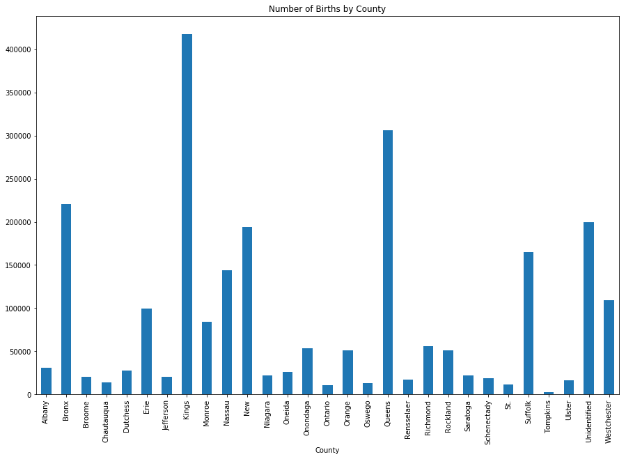

```python
county_name.plot(kind='bar', figsize=(15, 10), title="Number of Births by County")
```

### Sort Data by Number of Births

```python
sorted_county = county_name.sort_values()
sorted_county
```

```
County
Tompkins          2463
Ontario          10502
St.              11944
Oswego           13337
Chautauqua       14257
Ulster           16370
Rensselaer       17237
Schenectady      18423
Broome           20610
Jefferson        20750
Niagara          21919
Saratoga         22400
Oneida           25853
Dutchess         27682
Albany           30896
Rockland         50833
Orange           50990
Onondaga         53700
Richmond         55713
Monroe           84242
Erie             99150
Westchester     109197
Nassau          144178
Suffolk         164859
New             193665
Unidentified    199597
Bronx           220713
Queens          306512
Kings           417865
Name: Births, dtype: int64
```

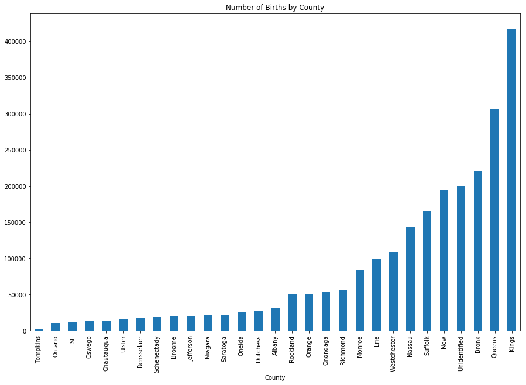

```python
sorted_county.plot(kind='bar', figsize=(15, 10), title="Number of Births by County")
```

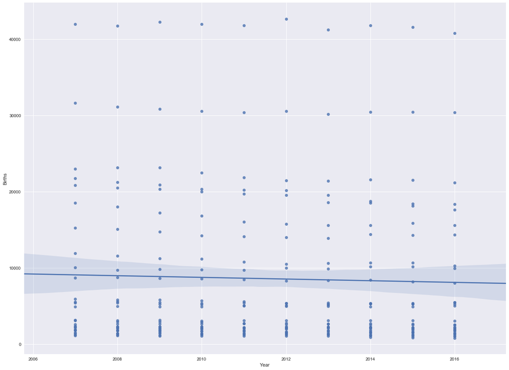

```python
import seaborn as sns
plt.figure(figsize=(20,15))
sns.set(color_codes=True)
g = sns.regplot(x='Year', y='Births', data=df)
```

## Census Data

```python
df2 = pd.read_csv('census2016income.csv')
```

```python
df2
```

|  | GEO.id | GEO.id2 | GEO.display-label | HC01_EST_VC01 | HC01_MOE_VC01 | HC02_EST_VC01 | HC02_MOE_VC01 | HC03_EST_VC01 | HC03_MOE_VC01 | HC04_EST_VC01 | ... | HC04_EST_VC19 | HC04_MOE_VC19 | HC01_EST_VC20 | HC01_MOE_VC20 | HC02_EST_VC20 | HC02_MOE_VC20 | HC03_EST_VC20 | HC03_MOE_VC20 | HC04_EST_VC20 | HC04_MOE_VC20 |
| --- | --- | --- | --- | --- | --- | --- | --- | --- | --- | --- | --- | --- | --- | --- | --- | --- | --- | --- | --- | --- | --- |
| 0 | 0500000US36001 | 36001 | Albany County, New York | 125329 | 2110 | 69122 | 2777 | 49765 | 2622 | 56207 | ... | (X) | (X) | (X) | (X) | (X) | (X) | (X) | (X) | 30.5 | (X) |
| 1 | 0500000US36005 | 36005 | Bronx County, New York | 498539 | 3078 | 331774 | 5984 | 143169 | 5990 | 166765 | ... | (X) | (X) | (X) | (X) | (X) | (X) | (X) | (X) | 34.7 | (X) |
| 2 | 0500000US36007 | 36007 | Broome County, New York | 76957 | 2045 | 46264 | 2257 | 34412 | 1646 | 30693 | ... | (X) | (X) | (X) | (X) | (X) | (X) | (X) | (X) | 38.3 | (X) |
| 3 | 0500000US36009 | 36009 | Cattaraugus County, New York | 31409 | 1137 | 19505 | 1091 | 13993 | 896 | 11904 | ... | (X) | (X) | (X) | (X) | (X) | (X) | (X) | (X) | 26.6 | (X) |
| 4 | 0500000US36011 | 36011 | Cayuga County, New York | 30966 | 1110 | 18539 | 1025 | 13311 | 1004 | 12427 | ... | (X) | (X) | (X) | (X) | (X) | (X) | (X) | (X) | 38.2 | (X) |
| 5 | 0500000US36013 | 36013 | Chautauqua County, New York | 51705 | 1835 | 31199 | 1743 | 24220 | 1593 | 20506 | ... | (X) | (X) | (X) | (X) | (X) | (X) | (X) | (X) | 32.5 | (X) |
| 6 | 0500000US36015 | 36015 | Chemung County, New York | 34418 | 1411 | 21203 | 1435 | N | N | 13215 | ... | (X) | (X) | (X) | (X) | (X) | (X) | (X) | (X) | 32.7 | (X) |
| 7 | 0500000US36019 | 36019 | Clinton County, New York | 30624 | 1203 | 20266 | 1295 | N | N | 10358 | ... | (X) | (X) | (X) | (X) | (X) | (X) | (X) | (X) | 30.7 | (X) |
| 8 | 0500000US36027 | 36027 | Dutchess County, New York | 108200 | 2382 | 71176 | 2722 | 53519 | 2496 | 37024 | ... | (X) | (X) | (X) | (X) | (X) | (X) | (X) | (X) | 36.1 | (X) |
| 9 | 0500000US36029 | 36029 | Erie County, New York | 380473 | 3446 | 222109 | 4616 | 155486 | 4264 | 158364 | ... | (X) | (X) | (X) | (X) | (X) | (X) | (X) | (X) | 33.4 | (X) |
| 10 | 0500000US36045 | 36045 | Jefferson County, New York | 41415 | 1556 | 28174 | 1594 | 21072 | 1639 | 13241 | ... | (X) | (X) | (X) | (X) | (X) | (X) | (X) | (X) | 30.4 | (X) |
| 11 | 0500000US36047 | 36047 | Kings County, New York | 941871 | 4738 | 575987 | 7226 | 348404 | 6751 | 365884 | ... | (X) | (X) | (X) | (X) | (X) | (X) | (X) | (X) | 41.4 | (X) |
| 12 | 0500000US36051 | 36051 | Livingston County, New York | 23904 | 915 | 14255 | 1223 | N | N | 9649 | ... | (X) | (X) | (X) | (X) | (X) | (X) | (X) | (X) | 32.5 | (X) |
| 13 | 0500000US36053 | 36053 | Madison County, New York | 25612 | 1346 | 15782 | 1248 | N | N | 9830 | ... | (X) | (X) | (X) | (X) | (X) | (X) | (X) | (X) | 47.7 | (X) |
| 14 | 0500000US36055 | 36055 | Monroe County, New York | 299224 | 3017 | 179894 | 4065 | 124925 | 4197 | 119330 | ... | (X) | (X) | (X) | (X) | (X) | (X) | (X) | (X) | 32.5 | (X) |
| 15 | 0500000US36059 | 36059 | Nassau County, New York | 440785 | 2860 | 337008 | 4904 | 268693 | 4900 | 103777 | ... | (X) | (X) | (X) | (X) | (X) | (X) | (X) | (X) | 40.8 | (X) |
| 16 | 0500000US36061 | 36061 | New York County, New York | 748293 | 8650 | 315379 | 9492 | 213998 | 7252 | 432914 | ... | (X) | (X) | (X) | (X) | (X) | (X) | (X) | (X) | 27.6 | (X) |
| 17 | 0500000US36063 | 36063 | Niagara County, New York | 86786 | 2310 | 54186 | 2348 | 38684 | 2236 | 32600 | ... | (X) | (X) | (X) | (X) | (X) | (X) | (X) | (X) | 32.6 | (X) |
| 18 | 0500000US36065 | 36065 | Oneida County, New York | 87929 | 2138 | 55064 | 2168 | 39305 | 2214 | 32865 | ... | (X) | (X) | (X) | (X) | (X) | (X) | (X) | (X) | 38.2 | (X) |
| 19 | 0500000US36067 | 36067 | Onondaga County, New York | 182984 | 3063 | 109911 | 3179 | 79651 | 2958 | 73073 | ... | (X) | (X) | (X) | (X) | (X) | (X) | (X) | (X) | 29.0 | (X) |
| 20 | 0500000US36069 | 36069 | Ontario County, New York | 45187 | 1314 | 29197 | 1648 | N | N | 15990 | ... | (X) | (X) | (X) | (X) | (X) | (X) | (X) | (X) | 27.2 | (X) |
| 21 | 0500000US36071 | 36071 | Orange County, New York | 124365 | 2193 | 86063 | 2742 | 66990 | 3070 | 38302 | ... | (X) | (X) | (X) | (X) | (X) | (X) | (X) | (X) | 49.3 | (X) |
| 22 | 0500000US36075 | 36075 | Oswego County, New York | 44633 | 1313 | 29386 | 1557 | 21300 | 1355 | 15247 | ... | (X) | (X) | (X) | (X) | (X) | (X) | (X) | (X) | 29.7 | (X) |
| 23 | 0500000US36079 | 36079 | Putnam County, New York | 34762 | 1247 | 25936 | 1446 | N | N | 8826 | ... | (X) | (X) | (X) | (X) | (X) | (X) | (X) | (X) | 35.7 | (X) |
| 24 | 0500000US36081 | 36081 | Queens County, New York | 761819 | 5689 | 505823 | 6595 | 340611 | 6388 | 255996 | ... | (X) | (X) | (X) | (X) | (X) | (X) | (X) | (X) | 39.5 | (X) |
| 25 | 0500000US36083 | 36083 | Rensselaer County, New York | 62816 | 1588 | 37775 | 2209 | 27188 | 1996 | 25041 | ... | (X) | (X) | (X) | (X) | (X) | (X) | (X) | (X) | 26.5 | (X) |
| 26 | 0500000US36085 | 36085 | Richmond County, New York | 164289 | 2449 | 121766 | 3227 | 90779 | 3724 | 42523 | ... | (X) | (X) | (X) | (X) | (X) | (X) | (X) | (X) | 43.2 | (X) |
| 27 | 0500000US36087 | 36087 | Rockland County, New York | 99257 | 1652 | 72925 | 2538 | 59470 | 2753 | 26332 | ... | (X) | (X) | (X) | (X) | (X) | (X) | (X) | (X) | 40.2 | (X) |
| 28 | 0500000US36089 | 36089 | St. Lawrence County, New York | 40479 | 1519 | 26548 | 1628 | 18412 | 1326 | 13931 | ... | (X) | (X) | (X) | (X) | (X) | (X) | (X) | (X) | 29.5 | (X) |
| 29 | 0500000US36091 | 36091 | Saratoga County, New York | 93703 | 1741 | 60786 | 2183 | 47999 | 2211 | 32917 | ... | (X) | (X) | (X) | (X) | (X) | (X) | (X) | (X) | 30.6 | (X) |
| 30 | 0500000US36093 | 36093 | Schenectady County, New York | 48720 | 1926 | 28959 | 1644 | N | N | 19761 | ... | (X) | (X) | (X) | (X) | (X) | (X) | (X) | (X) | 30.0 | (X) |
| 31 | 0500000US36101 | 36101 | Steuben County, New York | 38458 | 1164 | 25434 | 1303 | 18334 | 1340 | 13024 | ... | (X) | (X) | (X) | (X) | (X) | (X) | (X) | (X) | 25.5 | (X) |
| 32 | 0500000US36103 | 36103 | Suffolk County, New York | 474311 | 4927 | 349115 | 5998 | 272856 | 5516 | 125196 | ... | (X) | (X) | (X) | (X) | (X) | (X) | (X) | (X) | 36.9 | (X) |
| 33 | 0500000US36105 | 36105 | Sullivan County, New York | 25031 | 1701 | 16346 | 1601 | N | N | 8685 | ... | (X) | (X) | (X) | (X) | (X) | (X) | (X) | (X) | 38.2 | (X) |
| 34 | 0500000US36109 | 36109 | Tompkins County, New York | 37683 | 1516 | 20315 | 1586 | N | N | 17368 | ... | (X) | (X) | (X) | (X) | (X) | (X) | (X) | (X) | 26.2 | (X) |
| 35 | 0500000US36111 | 36111 | Ulster County, New York | 68298 | 2281 | 41957 | 2454 | 29890 | 1749 | 26341 | ... | (X) | (X) | (X) | (X) | (X) | (X) | (X) | (X) | 37.0 | (X) |
| 36 | 0500000US36113 | 36113 | Warren County, New York | 28841 | 1133 | 17013 | 1276 | N | N | 11828 | ... | (X) | (X) | (X) | (X) | (X) | (X) | (X) | (X) | 32.0 | (X) |
| 37 | 0500000US36117 | 36117 | Wayne County, New York | 37496 | 901 | 26178 | 1092 | N | N | 11318 | ... | (X) | (X) | (X) | (X) | (X) | (X) | (X) | (X) | 34.8 | (X) |
| 38 | 0500000US36119 | 36119 | Westchester County, New York | 342216 | 2884 | 235177 | 4347 | 175861 | 4762 | 107039 | ... | (X) | (X) | (X) | (X) | (X) | (X) | (X) | (X) | 35.4 | (X) |

39 rows × 131 columns

```python
df2.columns
```

```
Index(['GEO.id', 'GEO.id2', 'GEO.display-label', 'HC01_EST_VC01',
       'HC01_MOE_VC01', 'HC02_EST_VC01', 'HC02_MOE_VC01', 'HC03_EST_VC01',
       'HC03_MOE_VC01', 'HC04_EST_VC01',
       ...
       'HC04_EST_VC19', 'HC04_MOE_VC19', 'HC01_EST_VC20', 'HC01_MOE_VC20',
       'HC02_EST_VC20', 'HC02_MOE_VC20', 'HC03_EST_VC20', 'HC03_MOE_VC20',
       'HC04_EST_VC20', 'HC04_MOE_VC20'],
      dtype='object', length=131)
```

```python
#Rename columns

df2.rename(columns={'GEO.id2': 'County code', 'Geo.display-label': 'County name', 'HC01_EST_VC01': 'Households_estimate_total',
                    'HC01_MOE_VC01': 'Households_MOE_total', 'HC02_EST_VC01': 'Families_estimate_total',
                    'HC02_MOE_VC01': 'Familes_MOE_total', 'HC03_EST_VC01': 'Married-couple_families_estimate_total',
                    'HC03_MOE_VC01': 'Married-couple_families_MOE_total', 'HC04_EST_VC01': 'Nonfamily_households_estimate_total',
                    'HC04_MOE_VC01': 'Nonfamily_households_MOE_total'}, inplace=True)
```

```python
df2.columns
```

```
Index(['GEO.id', 'County code', 'GEO.display-label',
       'Households_estimate_total', 'Households_MOE_total',
       'Families_estimate_total', 'Familes_MOE_total',
       'Married-couple_families_estimate_total',
       'Married-couple_families_MOE_total',
       'Nonfamily_households_estimate_total',
       ...
       'HC04_EST_VC19', 'HC04_MOE_VC19', 'HC01_EST_VC20', 'HC01_MOE_VC20',
       'HC02_EST_VC20', 'HC02_MOE_VC20', 'HC03_EST_VC20', 'HC03_MOE_VC20',
       'HC04_EST_VC20', 'HC04_MOE_VC20'],
      dtype='object', length=131)
```

```python
# Delete first column

df2.drop(df2.columns[0], axis=1, inplace=True)
df2.head()
```

|  | County code | GEO.display-label | Households_estimate_total | Households_MOE_total | Families_estimate_total | Familes_MOE_total | Married-couple_families_estimate_total | Married-couple_families_MOE_total | Nonfamily_households_estimate_total | Nonfamily_households_MOE_total | ... | HC04_EST_VC19 | HC04_MOE_VC19 | HC01_EST_VC20 | HC01_MOE_VC20 | HC02_EST_VC20 | HC02_MOE_VC20 | HC03_EST_VC20 | HC03_MOE_VC20 | HC04_EST_VC20 | HC04_MOE_VC20 |
| --- | --- | --- | --- | --- | --- | --- | --- | --- | --- | --- | --- | --- | --- | --- | --- | --- | --- | --- | --- | --- | --- |
| 0 | 36001 | Albany County, New York | 125329 | 2110 | 69122 | 2777 | 49765 | 2622 | 56207 | 3237 | ... | (X) | (X) | (X) | (X) | (X) | (X) | (X) | (X) | 30.5 | (X) |
| 1 | 36005 | Bronx County, New York | 498539 | 3078 | 331774 | 5984 | 143169 | 5990 | 166765 | 5728 | ... | (X) | (X) | (X) | (X) | (X) | (X) | (X) | (X) | 34.7 | (X) |
| 2 | 36007 | Broome County, New York | 76957 | 2045 | 46264 | 2257 | 34412 | 1646 | 30693 | 2212 | ... | (X) | (X) | (X) | (X) | (X) | (X) | (X) | (X) | 38.3 | (X) |
| 3 | 36009 | Cattaraugus County, New York | 31409 | 1137 | 19505 | 1091 | 13993 | 896 | 11904 | 1136 | ... | (X) | (X) | (X) | (X) | (X) | (X) | (X) | (X) | 26.6 | (X) |
| 4 | 36011 | Cayuga County, New York | 30966 | 1110 | 18539 | 1025 | 13311 | 1004 | 12427 | 1115 | ... | (X) | (X) | (X) | (X) | (X) | (X) | (X) | (X) | 38.2 | (X) |

5 rows × 130 columns

```python
df2.columns
```

```
Index(['County code', 'GEO.display-label', 'Households_estimate_total',
       'Households_MOE_total', 'Families_estimate_total', 'Familes_MOE_total',
       'Married-couple_families_estimate_total',
       'Married-couple_families_MOE_total',
       'Nonfamily_households_estimate_total', 'Nonfamily_households_MOE_total',
       ...
       'HC04_EST_VC19', 'HC04_MOE_VC19', 'HC01_EST_VC20', 'HC01_MOE_VC20',
       'HC02_EST_VC20', 'HC02_MOE_VC20', 'HC03_EST_VC20', 'HC03_MOE_VC20',
       'HC04_EST_VC20', 'HC04_MOE_VC20'],
      dtype='object', length=130)
```

```python
# Print column names as a list to see all of it.

print(list(df2.columns))
```

```
['County code', 'GEO.display-label', 'Households_estimate_total', 'Households_MOE_total', 'Families_estimate_total', 'Familes_MOE_total', 'Married-couple_families_estimate_total', 'Married-couple_families_MOE_total', 'Nonfamily_households_estimate_total', 'Nonfamily_households_MOE_total', 'HC01_EST_…
```

### Rename Column Names in Household Data

```python
# Rename the rest of the columns

df2.rename(columns={'HC01_EST_VC02': 'Households:<$10,000', 'HC02_EST_VC02': 'Families:<$10,000',
                   'HC03_EST_VC02': 'Married-couple_families:<$10,000', 'HC04_EST_VC02': 'Nonfamily_households:<$10,000',
                   'HC01_EST_VC03': 'Households:$10,000-$14,999', 'HC02_EST_VC03': 'Families:$10,000-$14,999',
                   'HC03_EST_VC03': 'Married-couple_familes:$10,000-$14,999', 'HC04_EST_VC03': 'Nonfamily-households:$10,000-$14,999',
                   'HC01_EST_VC04': 'Households:$15,000-$24,999', 'HC02_EST_VC04': 'Families:$15,000-$24,999',
                   'HC03_EST_VC04': 'Married-couple_families:$15,000-$24,999', 'HC04_EST_VC04': 'Nonfamily_households:$15,000-$24,999',
                   'HC01_EST_VC05': 'Households:$25,000-$34,999', 'HC02_EST_VC05': 'Families:$25,000-$34,999', 'HC03_EST_VC05':
                   'Married-couple_families:$25,000-$34,999', 'HC04_EST_VC05': 'Nonfamily_households:$25,000-$34,999',
                   'HC01_EST_VC06': 'Households:$35,000-$49,999', 'HC02_EST_VC06': 'Families:$35,000-$49,999',
                   'HC03_EST_VC06': 'Married-couple_families:$35,000-$49,999', 'HC04_EST_VC06': 'Nonfamily_households:$35,000-$49,999',
                   'HC01_EST_VC07': 'Households:$50,000-$74,999', 'HC02_EST_VC07': 'Families:$50,000-$74,999',
                   'HC03_EST_VC07': 'Married-couple_families:$50,000-$74,999', 'HC04_EST_VC07': 'Nonfamily_households:$50,000-$74,999',
                   'HC01_EST_VC08': 'Households:$75,000-$99,999', 'HC02_EST_VC08': 'Families:$75,000-$99,999',
                   'HC03_EST_VC08': 'Married-couple_families:$75,000-$99,999', 'HC04_EST_VC08': 'Nonfamily_households:$75,000-$99,999',
                   'HC01_EST_VC09': 'Households:$100,000-$149,999', 'HC02_EST_VC09': 'Families:$100,000-$149,999',
                   'HC03_EST_VC09': 'Married-couple_families:$100,000-$149,999',
                   'HC04_EST_VC09': 'Nonfamiliy_households:$100,000-$149,999', 'HC01_EST_VC10': 'Households:$150,000-$199,999',
                   'HC02_EST_VC10': 'Families:$150,000-$199,999', 'HC03_EST_VC10': 'Married-couple_families:$150,000-$199,999',
                   'HC04_EST_VC10': 'Nonfamily_households:$150,000-$199,999', 'HC01_EST_VC11': 'Households:$200,000_or_more',
                   'HC02_EST_VC11': 'Families:$200,000_or_more', 'HC03_EST_VC11': 'Married-couple_families:$200,000_or_more',
                   'HC04_EST_VC11': 'Nonfamily_households:$200,000_or_more', 'HC01_EST_VC13': 'Households:Median_income',
                   'HC02_EST_VC13': 'Families:Median_income', 'HC03_EST_VC13': 'Married-couple_families:Median_income',
                   'HC04_EST_VC13': 'Nonfamily_households:Median_income', 'HC01_EST_VC15': 'Households:Mean_income',
                   'HC02_EST_VC15': 'Families:Mean_income', 'HC03_EST_VC15': 'Married-couple_households:Mean_income',
                   'HC04_EST_VC15': 'Nonfamily_households:Mean_income'}, inplace=True)
```

```python
print(list(df2.columns))
```

```
['County code', 'GEO.display-label', 'Households_estimate_total', 'Households_MOE_total', 'Families_estimate_total', 'Familes_MOE_total', 'Married-couple_families_estimate_total', 'Married-couple_families_MOE_total', 'Nonfamily_households_estimate_total', 'Nonfamily_households_MOE_total', 'Household…
```

```python
#df.drop('County', axis=1, inplace=True)

df2.rename(columns={'GEO.display-label': 'County_name'}, inplace=True)
```

```python
df2.drop(['Households_MOE_total', 'Familes_MOE_total'], axis=1, inplace=True)
```

```python
print(list(df2.columns))
```

```
['County code', 'County_name', 'Households_estimate_total', 'Families_estimate_total', 'Married-couple_families_estimate_total', 'Married-couple_families_MOE_total', 'Nonfamily_households_estimate_total', 'Nonfamily_households_MOE_total', 'Households:<$10,000', 'HC01_MOE_VC02', 'Families:<$10,000', …
```

```python
# Delete columns that are not needed

df2.drop(['Married-couple_families_MOE_total', 'Nonfamily_households_MOE_total', 'HC01_MOE_VC02', 'HC02_MOE_VC02',
          'HC03_MOE_VC02', 'HC04_MOE_VC02', 'HC01_MOE_VC03', 'HC02_MOE_VC03', 'HC03_MOE_VC03', 'HC04_MOE_VC03',
          'HC01_MOE_VC04', 'HC02_MOE_VC04', 'HC03_MOE_VC04', 'HC04_MOE_VC04', 'HC01_MOE_VC05', 'HC02_MOE_VC05',
          'HC03_MOE_VC05', 'HC04_MOE_VC05', 'HC01_MOE_VC06', 'HC02_MOE_VC06', 'HC03_MOE_VC06', 'HC04_MOE_VC06',
          'HC01_MOE_VC07', 'HC02_MOE_VC07', 'HC03_MOE_VC07', 'HC04_MOE_VC07', 'HC01_MOE_VC08', 'HC02_MOE_VC08',
          'HC03_MOE_VC08', 'HC04_MOE_VC08', 'HC01_MOE_VC09', 'HC02_MOE_VC09', 'HC03_MOE_VC09', 'HC04_MOE_VC09',
          'HC01_MOE_VC10', 'HC02_MOE_VC10', 'HC03_MOE_VC10', 'HC04_MOE_VC10', 'HC01_MOE_VC11', 'HC02_MOE_VC11',
          'HC03_MOE_VC11', 'HC04_MOE_VC11', 'HC01_MOE_VC13', 'HC02_MOE_VC13', 'HC03_MOE_VC13', 'HC04_MOE_VC13',
          'HC01_MOE_VC15', 'HC02_MOE_VC15', 'HC03_MOE_VC15', 'HC04_MOE_VC15', 'HC01_EST_VC18', 'HC01_MOE_VC18',
          'HC02_EST_VC18', 'HC02_MOE_VC18', 'HC03_EST_VC18', 'HC03_MOE_VC18', 'HC04_EST_VC18', 'HC04_MOE_VC18',
          'HC01_EST_VC19', 'HC01_MOE_VC19', 'HC02_EST_VC19', 'HC02_MOE_VC19', 'HC03_EST_VC19', 'HC03_MOE_VC19',
          'HC04_EST_VC19', 'HC04_MOE_VC19', 'HC01_EST_VC20', 'HC01_MOE_VC20', 'HC02_EST_VC20', 'HC02_MOE_VC20',
          'HC03_EST_VC20', 'HC03_MOE_VC20', 'HC04_EST_VC20', 'HC04_MOE_VC20'], axis=1, inplace=True)
```

```python
print(list(df2.columns))
```

```
['County code', 'County_name', 'Households_estimate_total', 'Families_estimate_total', 'Married-couple_families_estimate_total', 'Nonfamily_households_estimate_total', 'Households:<$10,000', 'Families:<$10,000', 'Married-couple_families:<$10,000', 'Nonfamily_households:<$10,000', 'Households:$10,000…
```

```python
df2.head()
```

|  | County code | County_name | Households_estimate_total | Families_estimate_total | Married-couple_families_estimate_total | Nonfamily_households_estimate_total | Households:<$10,000 | Families:<$10,000 | Married-couple_families:<$10,000 | Nonfamily_households:<$10,000 | ... | Married-couple_families:$200,000_or_more | Nonfamily_households:$200,000_or_more | Households:Median_income | Families:Median_income | Married-couple_families:Median_income | Nonfamily_households:Median_income | Households:Mean_income | Families:Mean_income | Married-couple_households:Mean_income | Nonfamily_households:Mean_income |
| --- | --- | --- | --- | --- | --- | --- | --- | --- | --- | --- | --- | --- | --- | --- | --- | --- | --- | --- | --- | --- | --- |
| 0 | 36001 | Albany County, New York | 125329 | 69122 | 49765 | 56207 | 6.2 | 3.0 | 0.8 | 10.8 | ... | 14.5 | 1.9 | 61754 | 85897 | 107425 | 40299 | 83464 | 106202 | N | 52871 |
| 1 | 36005 | Bronx County, New York | 498539 | 331774 | 143169 | 166765 | 14.4 | 10.0 | 2.6 | 25.8 | ... | 4.5 | 0.7 | 37525 | 42602 | 61249 | 23673 | 53466 | 59196 | 79371 | 36561 |
| 2 | 36007 | Broome County, New York | 76957 | 46264 | 34412 | 30693 | 6.5 | 3.9 | 0.9 | 11.5 | ... | 5.6 | 0.8 | 50463 | 63692 | 75885 | 26920 | 67239 | 82375 | N | 41473 |
| 3 | 36009 | Cattaraugus County, New York | 31409 | 19505 | 13993 | 11904 | 7.9 | 3.4 | 0.2 | 16.6 | ... | 1.9 | 0.5 | 46842 | 57699 | 72245 | 25977 | 57722 | 69266 | N | 36092 |
| 4 | 36011 | Cayuga County, New York | 30966 | 18539 | 13311 | 12427 | 6.0 | 5.0 | 1.2 | 9.4 | ... | 4.0 | 1.2 | 54995 | 66121 | 77689 | 36164 | 68575 | 76794 | N | 51709 |

5 rows × 54 columns

### Population per Household Plotted

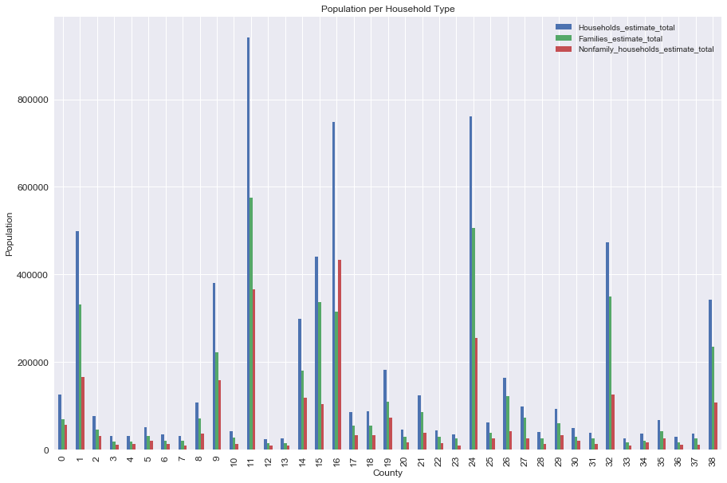

```python
ax = df2[['Households_estimate_total', 'Families_estimate_total', 'Married-couple_families_estimate_total',
          'Nonfamily_households_estimate_total']].plot(kind='bar', title ="Population per Household Type",
                                                       figsize=(15, 10), legend=True, fontsize=12)
ax.set_xlabel("County", fontsize=12)
ax.set_ylabel("Population", fontsize=12)
plt.show()
```

```python
df2
```

|  | County code | County_name | Households_estimate_total | Families_estimate_total | Married-couple_families_estimate_total | Nonfamily_households_estimate_total | Households:<$10,000 | Families:<$10,000 | Married-couple_families:<$10,000 | Nonfamily_households:<$10,000 | ... | Married-couple_families:$200,000_or_more | Nonfamily_households:$200,000_or_more | Households:Median_income | Families:Median_income | Married-couple_families:Median_income | Nonfamily_households:Median_income | Households:Mean_income | Families:Mean_income | Married-couple_households:Mean_income | Nonfamily_households:Mean_income |
| --- | --- | --- | --- | --- | --- | --- | --- | --- | --- | --- | --- | --- | --- | --- | --- | --- | --- | --- | --- | --- | --- |
| 0 | 36001 | Albany County, New York | 125329 | 69122 | 49765 | 56207 | 6.2 | 3.0 | 0.8 | 10.8 | ... | 14.5 | 1.9 | 61754 | 85897 | 107425 | 40299 | 83464 | 106202 | N | 52871 |
| 1 | 36005 | Bronx County, New York | 498539 | 331774 | 143169 | 166765 | 14.4 | 10.0 | 2.6 | 25.8 | ... | 4.5 | 0.7 | 37525 | 42602 | 61249 | 23673 | 53466 | 59196 | 79371 | 36561 |
| 2 | 36007 | Broome County, New York | 76957 | 46264 | 34412 | 30693 | 6.5 | 3.9 | 0.9 | 11.5 | ... | 5.6 | 0.8 | 50463 | 63692 | 75885 | 26920 | 67239 | 82375 | N | 41473 |
| 3 | 36009 | Cattaraugus County, New York | 31409 | 19505 | 13993 | 11904 | 7.9 | 3.4 | 0.2 | 16.6 | ... | 1.9 | 0.5 | 46842 | 57699 | 72245 | 25977 | 57722 | 69266 | N | 36092 |
| 4 | 36011 | Cayuga County, New York | 30966 | 18539 | 13311 | 12427 | 6.0 | 5.0 | 1.2 | 9.4 | ... | 4.0 | 1.2 | 54995 | 66121 | 77689 | 36164 | 68575 | 76794 | N | 51709 |
| 5 | 36013 | Chautauqua County, New York | 51705 | 31199 | 24220 | 20506 | 7.5 | 4.0 | 1.4 | 14.1 | ... | 1.1 | 1.3 | 42204 | 56959 | 65584 | 24519 | 55539 | 66524 | N | 37461 |
| 6 | 36015 | Chemung County, New York | 34418 | 21203 | N | 13215 | 7.5 | 2.7 | N | 15.8 | ... | N | 1.4 | 51269 | 69651 | 82609 | 23150 | 67332 | 82566 | N | 39057 |
| 7 | 36019 | Clinton County, New York | 30624 | 20266 | N | 10358 | 5.7 | 5.1 | N | 10.9 | ... | N | 0.0 | 55316 | 64266 | 72724 | 32279 | 65214 | 73337 | N | 43961 |
| 8 | 36027 | Dutchess County, New York | 108200 | 71176 | 53519 | 37024 | 3.7 | 2.0 | 0.7 | 7.7 | ... | 14.9 | 3.3 | 74115 | 91993 | 110525 | 42124 | 99958 | 117569 | N | 62794 |
| 9 | 36029 | Erie County, New York | 380473 | 222109 | 155486 | 158364 | 8.2 | 4.4 | 1.9 | 14.3 | ... | 8.9 | 1.3 | 54246 | 73253 | 90175 | 31841 | 73544 | 92176 | 108991 | 45212 |
| 10 | 36045 | Jefferson County, New York | 41415 | 28174 | 21072 | 13241 | 8.4 | 5.5 | 1.9 | 17.6 | ... | 2.5 | 1.5 | 45624 | 55102 | 67431 | 27975 | 61225 | 68344 | N | 42343 |
| 11 | 36047 | Kings County, New York | 941871 | 575987 | 348404 | 365884 | 10.7 | 6.0 | 2.5 | 18.9 | ... | 13.5 | 4.3 | 55150 | 61989 | 79148 | 41030 | 83115 | 92770 | 114784 | 62717 |
| 12 | 36051 | Livingston County, New York | 23904 | 14255 | N | 9649 | 7.0 | 5.5 | N | 9.6 | ... | N | 0.0 | 53121 | 65702 | 73527 | 35027 | 61229 | 74351 | N | 39391 |
| 13 | 36053 | Madison County, New York | 25612 | 15782 | N | 9830 | 4.8 | 1.9 | N | 9.7 | ... | N | 1.7 | 60630 | 83422 | 95233 | 31954 | 76630 | 95147 | N | 44304 |
| 14 | 36055 | Monroe County, New York | 299224 | 179894 | 124925 | 119330 | 8.3 | 5.1 | 1.7 | 13.7 | ... | 9.1 | 1.2 | 54492 | 73088 | 93838 | 33895 | 74700 | 91518 | 111182 | 46987 |
| 15 | 36059 | Nassau County, New York | 440785 | 337008 | 268693 | 103777 | 3.0 | 1.5 | 0.6 | 8.6 | ... | 27.7 | 4.4 | 105870 | 125601 | 139786 | 43643 | 139034 | 158896 | 174729 | 67061 |
| 16 | 36061 | New York County, New York | 748293 | 315379 | 213998 | 432914 | 9.4 | 5.6 | 2.2 | 12.6 | ... | 41.2 | 13.4 | 77559 | 99195 | 157287 | 67843 | 143741 | 195026 | 257569 | 104969 |
| 17 | 36063 | Niagara County, New York | 86786 | 54186 | 38684 | 32600 | 6.6 | 2.8 | 0.5 | 13.1 | ... | 4.1 | 0.7 | 50233 | 68775 | 86490 | 31352 | 65869 | 79627 | N | 39581 |
| 18 | 36065 | Oneida County, New York | 87929 | 55064 | 39305 | 32865 | 7.7 | 5.7 | 2.3 | 12.9 | ... | 6.0 | 0.6 | 52996 | 67107 | 77268 | 30846 | 68695 | 82581 | 96525 | 41405 |
| 19 | 36067 | Onondaga County, New York | 182984 | 109911 | 79651 | 73073 | 7.8 | 4.5 | 1.9 | 13.7 | ... | 8.1 | 1.6 | 56991 | 76453 | 91710 | 33844 | 76174 | 93616 | 110749 | 46823 |
| 20 | 36069 | Ontario County, New York | 45187 | 29197 | N | 15990 | 3.8 | 4.4 | N | 6.6 | ... | N | 0.8 | 57448 | 76497 | 92546 | 35712 | 78032 | 95296 | N | 41661 |
| 21 | 36071 | Orange County, New York | 124365 | 86063 | 66990 | 38302 | 5.6 | 3.7 | 2.1 | 10.1 | ... | 12.4 | 3.1 | 73025 | 89797 | 105732 | 38069 | 91061 | 104983 | 118359 | 56367 |
| 22 | 36075 | Oswego County, New York | 44633 | 29386 | 21300 | 15247 | 6.5 | 5.8 | 2.0 | 10.3 | ... | 3.7 | 1.5 | 53562 | 63639 | 76014 | 33491 | 65090 | 74438 | N | 43404 |
| 23 | 36079 | Putnam County, New York | 34762 | 25936 | N | 8826 | 0.8 | 0.7 | N | 1.1 | ... | N | 3.6 | 96992 | 115978 | 127603 | 50000 | 122979 | 140021 | N | 70562 |
| 24 | 36081 | Queens County, New York | 761819 | 505823 | 340611 | 255996 | 6.9 | 4.1 | 2.3 | 13.4 | ... | 8.9 | 2.4 | 62207 | 70538 | 81299 | 42671 | 81379 | 89303 | 100292 | 59597 |
| 25 | 36083 | Rensselaer County, New York | 62816 | 37775 | 27188 | 25041 | 4.5 | 3.8 | 1.1 | 7.0 | ... | 9.1 | 1.8 | 65965 | 83174 | 103303 | 37377 | 80856 | 96807 | N | 50305 |
| 26 | 36085 | Richmond County, New York | 164289 | 121766 | 90779 | 42523 | 9.2 | 5.5 | 2.1 | 21.1 | ... | 14.6 | 1.2 | 77197 | 93093 | 106673 | 34500 | 95481 | 110238 | 125128 | 47645 |
| 27 | 36087 | Rockland County, New York | 99257 | 72925 | 59470 | 26332 | 4.0 | 3.1 | 2.4 | 6.5 | ... | 22.2 | 5.5 | 85515 | 101100 | 112463 | 51545 | 116116 | 129729 | N | 71484 |
| 28 | 36089 | St. Lawrence County, New York | 40479 | 26548 | 18412 | 13931 | 6.5 | 4.4 | 2.7 | 12.4 | ... | 3.6 | 1.6 | 51592 | 60475 | 72624 | 28774 | 64088 | 71713 | N | 45696 |
| 29 | 36091 | Saratoga County, New York | 93703 | 60786 | 47999 | 32917 | 4.0 | 1.9 | 0.5 | 8.3 | ... | 13.9 | 2.5 | 76097 | 92050 | 103409 | 45562 | 99966 | 118985 | N | 59954 |
| 30 | 36093 | Schenectady County, New York | 48720 | 28959 | N | 19761 | 4.0 | 1.5 | N | 8.2 | ... | N | 0.8 | 58331 | 76279 | 89212 | 34293 | 75564 | 92631 | N | 47989 |
| 31 | 36101 | Steuben County, New York | 38458 | 25434 | 18334 | 13024 | 4.2 | 3.0 | 0.4 | 8.7 | ... | 4.0 | 1.7 | 50575 | 59901 | 71363 | 31958 | 69894 | 74981 | N | 56139 |
| 32 | 36103 | Suffolk County, New York | 474311 | 349115 | 272856 | 125196 | 3.5 | 2.2 | 0.8 | 8.8 | ... | 19.6 | 4.3 | 92933 | 107747 | 122043 | 47270 | 118609 | 133523 | 147904 | 68706 |
| 33 | 36105 | Sullivan County, New York | 25031 | 16346 | N | 8685 | 6.7 | 3.5 | N | 12.9 | ... | N | 3.4 | 50652 | 70403 | 83333 | 29474 | 76471 | 92383 | N | 43934 |
| 34 | 36109 | Tompkins County, New York | 37683 | 20315 | N | 17368 | 11.8 | 4.5 | N | 20.6 | ... | N | 2.1 | 56349 | 78948 | 91513 | 31051 | 73644 | 96948 | N | 42235 |
| 35 | 36111 | Ulster County, New York | 68298 | 41957 | 29890 | 26341 | 4.9 | 3.7 | 1.9 | 7.2 | ... | 13.4 | 1.1 | 62790 | 78407 | 95033 | 31734 | 82176 | 100833 | 117805 | 48383 |
| 36 | 36113 | Warren County, New York | 28841 | 17013 | N | 11828 | 5.0 | 2.8 | N | 9.3 | ... | N | 1.1 | 58061 | 71433 | 85905 | 35239 | 75717 | 91408 | N | 49656 |
| 37 | 36117 | Wayne County, New York | 37496 | 26178 | N | 11318 | 3.5 | 2.7 | N | 6.7 | ... | N | 1.3 | 59538 | 64662 | 75681 | 36527 | 70422 | 75563 | N | 51847 |
| 38 | 36119 | Westchester County, New York | 342216 | 235177 | 175861 | 107039 | 5.4 | 2.7 | 1.4 | 11.8 | ... | 32.1 | 4.6 | 89709 | 113190 | 138971 | 47468 | 141104 | 170464 | N | 72004 |

39 rows × 54 columns